# Optimal Treatment Analysis

## Outcome Variable

**Outcome Variable:** ever_stunted

## Predictor Variables

**Intervention Variable:** anywast06

**Adjustment Set:**

- arm
- sex
- W_mage
- meducyrs
- month
- brthmon
- W_parity
- delta_W_mage
- delta_meducyrs
- delta_month
- delta_brthmon
- delta_W_parity

## Stratifying Variables

The analysis was stratified on these variable(s):

- agecat
- studyid
- country

## Data Summary

| agecat | studyid | country | anywast06 | ever_stunted | n_cell | n |
| --- | --- | --- | --- | --- | --- | --- |
| 0-24 months (no birth st.) | ki0047075b-MAL-ED | BANGLADESH | 0 | 0 | 76 | 217 |
| 0-24 months (no birth st.) | ki0047075b-MAL-ED | BANGLADESH | 0 | 1 | 92 | 217 |
| 0-24 months (no birth st.) | ki0047075b-MAL-ED | BANGLADESH | 1 | 0 | 28 | 217 |
| 0-24 months (no birth st.) | ki0047075b-MAL-ED | BANGLADESH | 1 | 1 | 21 | 217 |
| 0-24 months (no birth st.) | ki0047075b-MAL-ED | BRAZIL | 0 | 0 | 167 | 208 |
| 0-24 months (no birth st.) | ki0047075b-MAL-ED | BRAZIL | 0 | 1 | 27 | 208 |
| 0-24 months (no birth st.) | ki0047075b-MAL-ED | BRAZIL | 1 | 0 | 12 | 208 |
| 0-24 months (no birth st.) | ki0047075b-MAL-ED | BRAZIL | 1 | 1 | 2 | 208 |
| 0-24 months (no birth st.) | ki0047075b-MAL-ED | INDIA | 0 | 0 | 62 | 209 |
| 0-24 months (no birth st.) | ki0047075b-MAL-ED | INDIA | 0 | 1 | 82 | 209 |
| 0-24 months (no birth st.) | ki0047075b-MAL-ED | INDIA | 1 | 0 | 39 | 209 |
| 0-24 months (no birth st.) | ki0047075b-MAL-ED | INDIA | 1 | 1 | 26 | 209 |
| 0-24 months (no birth st.) | ki0047075b-MAL-ED | NEPAL | 0 | 0 | 132 | 212 |
| 0-24 months (no birth st.) | ki0047075b-MAL-ED | NEPAL | 0 | 1 | 45 | 212 |
| 0-24 months (no birth st.) | ki0047075b-MAL-ED | NEPAL | 1 | 0 | 25 | 212 |
| 0-24 months (no birth st.) | ki0047075b-MAL-ED | NEPAL | 1 | 1 | 10 | 212 |
| 0-24 months (no birth st.) | ki0047075b-MAL-ED | PERU | 0 | 0 | 112 | 266 |
| 0-24 months (no birth st.) | ki0047075b-MAL-ED | PERU | 0 | 1 | 146 | 266 |
| 0-24 months (no birth st.) | ki0047075b-MAL-ED | PERU | 1 | 0 | 3 | 266 |
| 0-24 months (no birth st.) | ki0047075b-MAL-ED | PERU | 1 | 1 | 5 | 266 |
| 0-24 months (no birth st.) | ki0047075b-MAL-ED | SOUTH AFRICA | 0 | 0 | 124 | 280 |
| 0-24 months (no birth st.) | ki0047075b-MAL-ED | SOUTH AFRICA | 0 | 1 | 127 | 280 |
| 0-24 months (no birth st.) | ki0047075b-MAL-ED | SOUTH AFRICA | 1 | 0 | 19 | 280 |
| 0-24 months (no birth st.) | ki0047075b-MAL-ED | SOUTH AFRICA | 1 | 1 | 10 | 280 |
| 0-24 months (no birth st.) | ki0047075b-MAL-ED | TANZANIA, UNITED REPUBLIC OF | 0 | 0 | 40 | 219 |
| 0-24 months (no birth st.) | ki0047075b-MAL-ED | TANZANIA, UNITED REPUBLIC OF | 0 | 1 | 170 | 219 |
| 0-24 months (no birth st.) | ki0047075b-MAL-ED | TANZANIA, UNITED REPUBLIC OF | 1 | 0 | 1 | 219 |
| 0-24 months (no birth st.) | ki0047075b-MAL-ED | TANZANIA, UNITED REPUBLIC OF | 1 | 1 | 8 | 219 |
| 0-24 months (no birth st.) | ki1000108-CMC-V-BCS-2002 | INDIA | 0 | 0 | 19 | 293 |
| 0-24 months (no birth st.) | ki1000108-CMC-V-BCS-2002 | INDIA | 0 | 1 | 118 | 293 |

[output cut: 198 more lines]

The following strata were considered:

- agecat: 0-24 months (no birth st.), studyid: ki0047075b-MAL-ED, country: BANGLADESH
- agecat: 0-24 months (no birth st.), studyid: ki0047075b-MAL-ED, country: BRAZIL
- agecat: 0-24 months (no birth st.), studyid: ki0047075b-MAL-ED, country: INDIA
- agecat: 0-24 months (no birth st.), studyid: ki0047075b-MAL-ED, country: NEPAL
- agecat: 0-24 months (no birth st.), studyid: ki0047075b-MAL-ED, country: PERU
- agecat: 0-24 months (no birth st.), studyid: ki0047075b-MAL-ED, country: SOUTH AFRICA
- agecat: 0-24 months (no birth st.), studyid: ki0047075b-MAL-ED, country: TANZANIA, UNITED REPUBLIC OF
- agecat: 0-24 months (no birth st.), studyid: ki1000108-CMC-V-BCS-2002, country: INDIA
- agecat: 0-24 months (no birth st.), studyid: ki1000108-IRC, country: INDIA
- agecat: 0-24 months (no birth st.), studyid: ki1000109-EE, country: PAKISTAN
- agecat: 0-24 months (no birth st.), studyid: ki1000109-ResPak, country: PAKISTAN
- agecat: 0-24 months (no birth st.), studyid: ki1017093b-PROVIDE, country: BANGLADESH
- agecat: 0-24 months (no birth st.), studyid: ki1066203-TanzaniaChild2, country: TANZANIA, UNITED REPUBLIC OF
- agecat: 0-24 months (no birth st.), studyid: ki1101329-Keneba, country: GAMBIA
- agecat: 0-24 months (no birth st.), studyid: ki1112895-Guatemala BSC, country: GUATEMALA
- agecat: 0-24 months (no birth st.), studyid: ki1113344-GMS-Nepal, country: NEPAL
- agecat: 0-24 months (no birth st.), studyid: ki1114097-CMIN, country: BANGLADESH
- agecat: 0-24 months (no birth st.), studyid: ki1114097-CMIN, country: PERU
- agecat: 0-24 months (no birth st.), studyid: ki1114097-CONTENT, country: PERU
- agecat: 0-6 months (no birth st.), studyid: ki0047075b-MAL-ED, country: BANGLADESH
- agecat: 0-6 months (no birth st.), studyid: ki0047075b-MAL-ED, country: BRAZIL
- agecat: 0-6 months (no birth st.), studyid: ki0047075b-MAL-ED, country: INDIA
- agecat: 0-6 months (no birth st.), studyid: ki0047075b-MAL-ED, country: NEPAL
- agecat: 0-6 months (no birth st.), studyid: ki0047075b-MAL-ED, country: PERU
- agecat: 0-6 months (no birth st.), studyid: ki0047075b-MAL-ED, country: SOUTH AFRICA
- agecat: 0-6 months (no birth st.), studyid: ki0047075b-MAL-ED, country: TANZANIA, UNITED REPUBLIC OF
- agecat: 0-6 months (no birth st.), studyid: ki1000108-CMC-V-BCS-2002, country: INDIA
- agecat: 0-6 months (no birth st.), studyid: ki1000108-IRC, country: INDIA
- agecat: 0-6 months (no birth st.), studyid: ki1000109-EE, country: PAKISTAN
- agecat: 0-6 months (no birth st.), studyid: ki1000109-ResPak, country: PAKISTAN
- agecat: 0-6 months (no birth st.), studyid: ki1017093b-PROVIDE, country: BANGLADESH
- agecat: 0-6 months (no birth st.), studyid: ki1066203-TanzaniaChild2, country: TANZANIA, UNITED REPUBLIC OF
- agecat: 0-6 months (no birth st.), studyid: ki1101329-Keneba, country: GAMBIA
- agecat: 0-6 months (no birth st.), studyid: ki1112895-Guatemala BSC, country: GUATEMALA
- agecat: 0-6 months (no birth st.), studyid: ki1113344-GMS-Nepal, country: NEPAL
- agecat: 0-6 months (no birth st.), studyid: ki1114097-CMIN, country: BANGLADESH
- agecat: 0-6 months (no birth st.), studyid: ki1114097-CMIN, country: PERU
- agecat: 0-6 months (no birth st.), studyid: ki1114097-CONTENT, country: PERU
- agecat: 6-24 months, studyid: ki0047075b-MAL-ED, country: BANGLADESH
- agecat: 6-24 months, studyid: ki0047075b-MAL-ED, country: BRAZIL
- agecat: 6-24 months, studyid: ki0047075b-MAL-ED, country: INDIA
- agecat: 6-24 months, studyid: ki0047075b-MAL-ED, country: NEPAL
- agecat: 6-24 months, studyid: ki0047075b-MAL-ED, country: PERU
- agecat: 6-24 months, studyid: ki0047075b-MAL-ED, country: SOUTH AFRICA
- agecat: 6-24 months, studyid: ki0047075b-MAL-ED, country: TANZANIA, UNITED REPUBLIC OF
- agecat: 6-24 months, studyid: ki1000108-CMC-V-BCS-2002, country: INDIA
- agecat: 6-24 months, studyid: ki1000108-IRC, country: INDIA
- agecat: 6-24 months, studyid: ki1000109-EE, country: PAKISTAN
- agecat: 6-24 months, studyid: ki1000109-ResPak, country: PAKISTAN
- agecat: 6-24 months, studyid: ki1017093b-PROVIDE, country: BANGLADESH
- agecat: 6-24 months, studyid: ki1066203-TanzaniaChild2, country: TANZANIA, UNITED REPUBLIC OF
- agecat: 6-24 months, studyid: ki1101329-Keneba, country: GAMBIA
- agecat: 6-24 months, studyid: ki1112895-Guatemala BSC, country: GUATEMALA
- agecat: 6-24 months, studyid: ki1113344-GMS-Nepal, country: NEPAL
- agecat: 6-24 months, studyid: ki1114097-CMIN, country: BANGLADESH
- agecat: 6-24 months, studyid: ki1114097-CMIN, country: PERU
- agecat: 6-24 months, studyid: ki1114097-CONTENT, country: PERU

### Dropped Strata

Some strata were dropped due to rare outcomes:

- agecat: 0-24 months (no birth st.), studyid: ki0047075b-MAL-ED, country: BRAZIL
- agecat: 0-24 months (no birth st.), studyid: ki0047075b-MAL-ED, country: PERU
- agecat: 0-24 months (no birth st.), studyid: ki0047075b-MAL-ED, country: TANZANIA, UNITED REPUBLIC OF
- agecat: 0-24 months (no birth st.), studyid: ki1112895-Guatemala BSC, country: GUATEMALA
- agecat: 0-24 months (no birth st.), studyid: ki1114097-CONTENT, country: PERU
- agecat: 0-6 months (no birth st.), studyid: ki0047075b-MAL-ED, country: BRAZIL
- agecat: 0-6 months (no birth st.), studyid: ki0047075b-MAL-ED, country: NEPAL
- agecat: 0-6 months (no birth st.), studyid: ki0047075b-MAL-ED, country: PERU
- agecat: 0-6 months (no birth st.), studyid: ki0047075b-MAL-ED, country: SOUTH AFRICA
- agecat: 0-6 months (no birth st.), studyid: ki0047075b-MAL-ED, country: TANZANIA, UNITED REPUBLIC OF
- agecat: 0-6 months (no birth st.), studyid: ki1112895-Guatemala BSC, country: GUATEMALA
- agecat: 0-6 months (no birth st.), studyid: ki1114097-CONTENT, country: PERU
- agecat: 6-24 months, studyid: ki0047075b-MAL-ED, country: BRAZIL
- agecat: 6-24 months, studyid: ki0047075b-MAL-ED, country: PERU
- agecat: 6-24 months, studyid: ki0047075b-MAL-ED, country: TANZANIA, UNITED REPUBLIC OF
- agecat: 6-24 months, studyid: ki1112895-Guatemala BSC, country: GUATEMALA
- agecat: 6-24 months, studyid: ki1114097-CONTENT, country: PERU

## Methods Detail

We’re interested in the causal parameters $E[Y_a]$ for all values of $a \in \mathcal{A}$. These parameters represent the mean outcome if, possibly contrary to fact, we intervened to set all units to have $A=a$. Under the randomization and positivity assumptions, these are identified by the statistical parameters $\psi_a=E_W[E_{Y|A,W}(Y|A=a,W)]$. In addition, we’re interested in the mean of $Y$, $E[Y]$ under no intervention (the observed mean). We will estimate these parameters by using SuperLearner to fit the relevant likelihood factors – $E_{Y|A,W}(Y|A=a,W)$ and $p(A=a|W)$, and then updating our likelihood fit using a joint TMLE.

For unadjusted analyses ($W=\{\}$), initial likelihoods were estimated using Lrnr_glm to estimate the simple $E(Y|A)$ and Lrnr_mean to estimate $p(A)$. For adjusted analyses, a small library containing Lrnr_glmnet, Lrnr_xgboost, and Lrnr_mean was used.

Having estimated these parameters, we will then use the delta method to estimate relative risks and attributable risks relative to a prespecified baseline level of $A$.

# Results Detail

## Results Plots

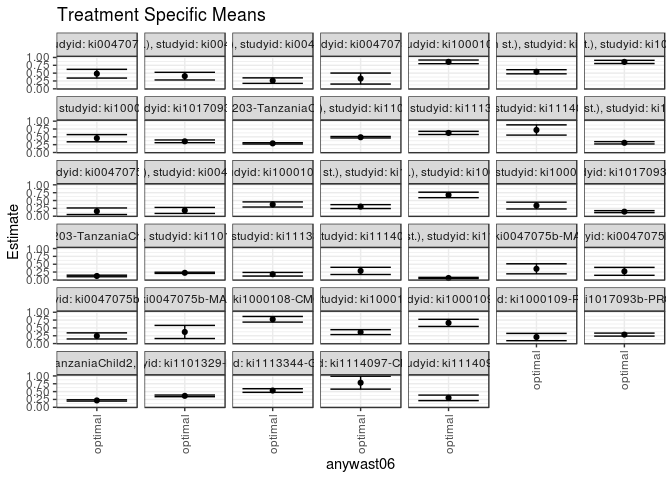

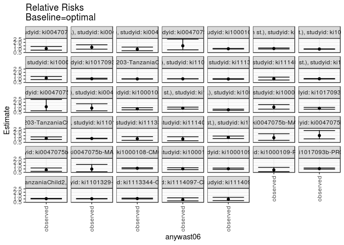

## Results Table

### Parameter: TSM

| agecat | studyid | country | intervention_level | baseline_level | estimate | ci_lower | ci_upper |
| --- | --- | --- | --- | --- | --- | --- | --- |
| 0-24 months (no birth st.) | ki0047075b-MAL-ED | BANGLADESH | optimal | NA | 0.4820876 | 0.3427276 | 0.6214477 |
| 0-24 months (no birth st.) | ki0047075b-MAL-ED | INDIA | optimal | NA | 0.4042438 | 0.2817134 | 0.5267742 |
| 0-24 months (no birth st.) | ki0047075b-MAL-ED | NEPAL | optimal | NA | 0.2614521 | 0.1735237 | 0.3493805 |
| 0-24 months (no birth st.) | ki0047075b-MAL-ED | SOUTH AFRICA | optimal | NA | 0.3269660 | 0.1514568 | 0.5024753 |
| 0-24 months (no birth st.) | ki1000108-CMC-V-BCS-2002 | INDIA | optimal | NA | 0.8600165 | 0.8013644 | 0.9186685 |
| 0-24 months (no birth st.) | ki1000108-IRC | INDIA | optimal | NA | 0.5442565 | 0.4783144 | 0.6101987 |
| 0-24 months (no birth st.) | ki1000109-EE | PAKISTAN | optimal | NA | 0.8580189 | 0.8063313 | 0.9097065 |
| 0-24 months (no birth st.) | ki1000109-ResPak | PAKISTAN | optimal | NA | 0.4560639 | 0.3412510 | 0.5708769 |
| 0-24 months (no birth st.) | ki1017093b-PROVIDE | BANGLADESH | optimal | NA | 0.3565029 | 0.3131821 | 0.3998237 |
| 0-24 months (no birth st.) | ki1066203-TanzaniaChild2 | TANZANIA, UNITED REPUBLIC OF | optimal | NA | 0.2914861 | 0.2711180 | 0.3118542 |
| 0-24 months (no birth st.) | ki1101329-Keneba | GAMBIA | optimal | NA | 0.4868794 | 0.4642332 | 0.5095255 |
| 0-24 months (no birth st.) | ki1113344-GMS-Nepal | NEPAL | optimal | NA | 0.6250939 | 0.5748825 | 0.6753054 |
| 0-24 months (no birth st.) | ki1114097-CMIN | BANGLADESH | optimal | NA | 0.7183189 | 0.5550656 | 0.8815721 |
| 0-24 months (no birth st.) | ki1114097-CMIN | PERU | optimal | NA | 0.3096203 | 0.2730001 | 0.3462404 |
| 0-6 months (no birth st.) | ki0047075b-MAL-ED | BANGLADESH | optimal | NA | 0.1578403 | 0.0531622 | 0.2625183 |
| 0-6 months (no birth st.) | ki0047075b-MAL-ED | INDIA | optimal | NA | 0.1839495 | 0.0878233 | 0.2800757 |
| 0-6 months (no birth st.) | ki1000108-CMC-V-BCS-2002 | INDIA | optimal | NA | 0.3742635 | 0.2922395 | 0.4562874 |
| 0-6 months (no birth st.) | ki1000108-IRC | INDIA | optimal | NA | 0.3069998 | 0.2446056 | 0.3693940 |
| 0-6 months (no birth st.) | ki1000109-EE | PAKISTAN | optimal | NA | 0.6776056 | 0.5895272 | 0.7656840 |
| 0-6 months (no birth st.) | ki1000109-ResPak | PAKISTAN | optimal | NA | 0.3392292 | 0.2305216 | 0.4479369 |
| 0-6 months (no birth st.) | ki1017093b-PROVIDE | BANGLADESH | optimal | NA | 0.1448210 | 0.1132192 | 0.1764229 |
| 0-6 months (no birth st.) | ki1066203-TanzaniaChild2 | TANZANIA, UNITED REPUBLIC OF | optimal | NA | 0.1244105 | 0.0990179 | 0.1498031 |
| 0-6 months (no birth st.) | ki1101329-Keneba | GAMBIA | optimal | NA | 0.2255218 | 0.2065531 | 0.2444905 |
| 0-6 months (no birth st.) | ki1113344-GMS-Nepal | NEPAL | optimal | NA | 0.1800287 | 0.1219249 | 0.2381326 |
| 0-6 months (no birth st.) | ki1114097-CMIN | BANGLADESH | optimal | NA | 0.2872681 | 0.1725983 | 0.4019379 |
| 0-6 months (no birth st.) | ki1114097-CMIN | PERU | optimal | NA | 0.0602437 | 0.0413985 | 0.0790889 |
| 6-24 months | ki0047075b-MAL-ED | BANGLADESH | optimal | NA | 0.3534363 | 0.1938704 | 0.5130023 |
| 6-24 months | ki0047075b-MAL-ED | INDIA | optimal | NA | 0.2723696 | 0.1459441 | 0.3987951 |
| 6-24 months | ki0047075b-MAL-ED | NEPAL | optimal | NA | 0.2443441 | 0.1469502 | 0.3417381 |
| 6-24 months | ki0047075b-MAL-ED | SOUTH AFRICA | optimal | NA | 0.3707208 | 0.1612357 | 0.5802058 |
| 6-24 months | ki1000108-CMC-V-BCS-2002 | INDIA | optimal | NA | 0.7755968 | 0.6860096 | 0.8651841 |
| 6-24 months | ki1000108-IRC | INDIA | optimal | NA | 0.3655725 | 0.2874132 | 0.4437317 |
| 6-24 months | ki1000109-EE | PAKISTAN | optimal | NA | 0.6603479 | 0.5460026 | 0.7746932 |
| 6-24 months | ki1000109-ResPak | PAKISTAN | optimal | NA | 0.2088791 | 0.0926218 | 0.3251364 |
| 6-24 months | ki1017093b-PROVIDE | BANGLADESH | optimal | NA | 0.2864941 | 0.2389642 | 0.3340240 |
| 6-24 months | ki1066203-TanzaniaChild2 | TANZANIA, UNITED REPUBLIC OF | optimal | NA | 0.2183382 | 0.1964157 | 0.2402608 |
| 6-24 months | ki1101329-Keneba | GAMBIA | optimal | NA | 0.3646269 | 0.3388690 | 0.3903848 |
| 6-24 months | ki1113344-GMS-Nepal | NEPAL | optimal | NA | 0.5340345 | 0.4763301 | 0.5917390 |
| 6-24 months | ki1114097-CMIN | BANGLADESH | optimal | NA | 0.7842569 | 0.5788529 | 0.9896609 |
| 6-24 months | ki1114097-CMIN | PERU | optimal | NA | 0.3007550 | 0.2128260 | 0.3886840 |

### Parameter: E(Y)

| agecat | studyid | country | intervention_level | baseline_level | estimate | ci_lower | ci_upper |
| --- | --- | --- | --- | --- | --- | --- | --- |
| 0-24 months (no birth st.) | ki0047075b-MAL-ED | BANGLADESH | observed | NA | 0.5207373 | 0.4541154 | 0.5873593 |
| 0-24 months (no birth st.) | ki0047075b-MAL-ED | INDIA | observed | NA | 0.5167464 | 0.4488350 | 0.5846578 |
| 0-24 months (no birth st.) | ki0047075b-MAL-ED | NEPAL | observed | NA | 0.2594340 | 0.2002911 | 0.3185768 |
| 0-24 months (no birth st.) | ki0047075b-MAL-ED | SOUTH AFRICA | observed | NA | 0.4892857 | 0.4306292 | 0.5479422 |
| 0-24 months (no birth st.) | ki1000108-CMC-V-BCS-2002 | INDIA | observed | NA | 0.9078498 | 0.8746748 | 0.9410249 |
| 0-24 months (no birth st.) | ki1000108-IRC | INDIA | observed | NA | 0.5916667 | 0.5408218 | 0.6425115 |
| 0-24 months (no birth st.) | ki1000109-EE | PAKISTAN | observed | NA | 0.8674699 | 0.8252704 | 0.9096693 |
| 0-24 months (no birth st.) | ki1000109-ResPak | PAKISTAN | observed | NA | 0.5198020 | 0.4507336 | 0.5888704 |
| 0-24 months (no birth st.) | ki1017093b-PROVIDE | BANGLADESH | observed | NA | 0.3753943 | 0.3376725 | 0.4131162 |
| 0-24 months (no birth st.) | ki1066203-TanzaniaChild2 | TANZANIA, UNITED REPUBLIC OF | observed | NA | 0.2988814 | 0.2798990 | 0.3178639 |
| 0-24 months (no birth st.) | ki1101329-Keneba | GAMBIA | observed | NA | 0.5044763 | 0.4837388 | 0.5252138 |
| 0-24 months (no birth st.) | ki1113344-GMS-Nepal | NEPAL | observed | NA | 0.6336449 | 0.5927799 | 0.6745099 |
| 0-24 months (no birth st.) | ki1114097-CMIN | BANGLADESH | observed | NA | 0.7559524 | 0.6908084 | 0.8210964 |
| 0-24 months (no birth st.) | ki1114097-CMIN | PERU | observed | NA | 0.3237082 | 0.2879308 | 0.3594857 |
| 0-6 months (no birth st.) | ki0047075b-MAL-ED | BANGLADESH | observed | NA | 0.2119816 | 0.1574763 | 0.2664868 |
| 0-6 months (no birth st.) | ki0047075b-MAL-ED | INDIA | observed | NA | 0.2105263 | 0.1551227 | 0.2659300 |
| 0-6 months (no birth st.) | ki1000108-CMC-V-BCS-2002 | INDIA | observed | NA | 0.3835616 | 0.3276935 | 0.4394298 |
| 0-6 months (no birth st.) | ki1000108-IRC | INDIA | observed | NA | 0.3444444 | 0.2952897 | 0.3935992 |
| 0-6 months (no birth st.) | ki1000109-EE | PAKISTAN | observed | NA | 0.6024096 | 0.5415000 | 0.6633193 |
| 0-6 months (no birth st.) | ki1000109-ResPak | PAKISTAN | observed | NA | 0.4356436 | 0.3670959 | 0.5041912 |
| 0-6 months (no birth st.) | ki1017093b-PROVIDE | BANGLADESH | observed | NA | 0.1593060 | 0.1307970 | 0.1878149 |
| 0-6 months (no birth st.) | ki1066203-TanzaniaChild2 | TANZANIA, UNITED REPUBLIC OF | observed | NA | 0.1369128 | 0.1226581 | 0.1511674 |
| 0-6 months (no birth st.) | ki1101329-Keneba | GAMBIA | observed | NA | 0.2412713 | 0.2235253 | 0.2590172 |
| 0-6 months (no birth st.) | ki1113344-GMS-Nepal | NEPAL | observed | NA | 0.1869159 | 0.1538509 | 0.2199809 |
| 0-6 months (no birth st.) | ki1114097-CMIN | BANGLADESH | observed | NA | 0.2857143 | 0.2171983 | 0.3542303 |
| 0-6 months (no birth st.) | ki1114097-CMIN | PERU | observed | NA | 0.0744681 | 0.0543935 | 0.0945427 |
| 6-24 months | ki0047075b-MAL-ED | BANGLADESH | observed | NA | 0.4213836 | 0.3443902 | 0.4983771 |
| 6-24 months | ki0047075b-MAL-ED | INDIA | observed | NA | 0.4129032 | 0.3351414 | 0.4906651 |
| 6-24 months | ki0047075b-MAL-ED | NEPAL | observed | NA | 0.2102564 | 0.1529155 | 0.2675974 |
| 6-24 months | ki0047075b-MAL-ED | SOUTH AFRICA | observed | NA | 0.3647799 | 0.2897219 | 0.4398379 |
| 6-24 months | ki1000108-CMC-V-BCS-2002 | INDIA | observed | NA | 0.8508287 | 0.7987841 | 0.9028733 |
| 6-24 months | ki1000108-IRC | INDIA | observed | NA | 0.3771186 | 0.3151523 | 0.4390850 |
| 6-24 months | ki1000109-EE | PAKISTAN | observed | NA | 0.6804124 | 0.5871313 | 0.7736934 |
| 6-24 months | ki1000109-ResPak | PAKISTAN | observed | NA | 0.1789474 | 0.1014597 | 0.2564350 |
| 6-24 months | ki1017093b-PROVIDE | BANGLADESH | observed | NA | 0.2997812 | 0.2577294 | 0.3418330 |
| 6-24 months | ki1066203-TanzaniaChild2 | TANZANIA, UNITED REPUBLIC OF | observed | NA | 0.2259675 | 0.2054816 | 0.2464534 |
| 6-24 months | ki1101329-Keneba | GAMBIA | observed | NA | 0.3752393 | 0.3512585 | 0.3992201 |
| 6-24 months | ki1113344-GMS-Nepal | NEPAL | observed | NA | 0.5610329 | 0.5138522 | 0.6082135 |
| 6-24 months | ki1114097-CMIN | BANGLADESH | observed | NA | 0.7117117 | 0.6270636 | 0.7963598 |
| 6-24 months | ki1114097-CMIN | PERU | observed | NA | 0.2892416 | 0.2518881 | 0.3265951 |

### Parameter: RR

| agecat | studyid | country | intervention_level | baseline_level | estimate | ci_lower | ci_upper |
| --- | --- | --- | --- | --- | --- | --- | --- |
| 0-24 months (no birth st.) | ki0047075b-MAL-ED | BANGLADESH | observed | optimal | 1.0801715 | 0.8399114 | 1.3891590 |
| 0-24 months (no birth st.) | ki0047075b-MAL-ED | INDIA | observed | optimal | 1.2783038 | 0.9892195 | 1.6518687 |
| 0-24 months (no birth st.) | ki0047075b-MAL-ED | NEPAL | observed | optimal | 0.9922811 | 0.7579480 | 1.2990624 |
| 0-24 months (no birth st.) | ki0047075b-MAL-ED | SOUTH AFRICA | observed | optimal | 1.4964420 | 0.8955288 | 2.5005771 |
| 0-24 months (no birth st.) | ki1000108-CMC-V-BCS-2002 | INDIA | observed | optimal | 1.0556191 | 1.0103643 | 1.1029009 |
| 0-24 months (no birth st.) | ki1000108-IRC | INDIA | observed | optimal | 1.0871099 | 1.0097988 | 1.1703400 |
| 0-24 months (no birth st.) | ki1000109-EE | PAKISTAN | observed | optimal | 1.0110149 | 0.9807193 | 1.0422463 |
| 0-24 months (no birth st.) | ki1000109-ResPak | PAKISTAN | observed | optimal | 1.1397568 | 0.9322780 | 1.3934100 |
| 0-24 months (no birth st.) | ki1017093b-PROVIDE | BANGLADESH | observed | optimal | 1.0529910 | 0.9882297 | 1.1219962 |
| 0-24 months (no birth st.) | ki1066203-TanzaniaChild2 | TANZANIA, UNITED REPUBLIC OF | observed | optimal | 1.0253712 | 0.9974275 | 1.0540978 |
| 0-24 months (no birth st.) | ki1101329-Keneba | GAMBIA | observed | optimal | 1.0361423 | 1.0167959 | 1.0558567 |
| 0-24 months (no birth st.) | ki1113344-GMS-Nepal | NEPAL | observed | optimal | 1.0136794 | 0.9684742 | 1.0609946 |
| 0-24 months (no birth st.) | ki1114097-CMIN | BANGLADESH | observed | optimal | 1.0523911 | 0.8585872 | 1.2899412 |
| 0-24 months (no birth st.) | ki1114097-CMIN | PERU | observed | optimal | 1.0455008 | 1.0094185 | 1.0828728 |
| 0-6 months (no birth st.) | ki0047075b-MAL-ED | BANGLADESH | observed | optimal | 1.3430134 | 0.7373493 | 2.4461742 |
| 0-6 months (no birth st.) | ki0047075b-MAL-ED | INDIA | observed | optimal | 1.1444789 | 0.7343298 | 1.7837108 |
| 0-6 months (no birth st.) | ki1000108-CMC-V-BCS-2002 | INDIA | observed | optimal | 1.0248439 | 0.8743098 | 1.2012963 |
| 0-6 months (no birth st.) | ki1000108-IRC | INDIA | observed | optimal | 1.1219697 | 0.9824087 | 1.2813567 |
| 0-6 months (no birth st.) | ki1000109-EE | PAKISTAN | observed | optimal | 0.8890269 | 0.8011484 | 0.9865448 |
| 0-6 months (no birth st.) | ki1000109-ResPak | PAKISTAN | observed | optimal | 1.2842158 | 0.9873312 | 1.6703719 |
| 0-6 months (no birth st.) | ki1017093b-PROVIDE | BANGLADESH | observed | optimal | 1.1000197 | 0.9739854 | 1.2423630 |
| 0-6 months (no birth st.) | ki1066203-TanzaniaChild2 | TANZANIA, UNITED REPUBLIC OF | observed | optimal | 1.1004919 | 0.9221748 | 1.3132894 |
| 0-6 months (no birth st.) | ki1101329-Keneba | GAMBIA | observed | optimal | 1.0698357 | 1.0298324 | 1.1113928 |
| 0-6 months (no birth st.) | ki1113344-GMS-Nepal | NEPAL | observed | optimal | 1.0382560 | 0.7943182 | 1.3571080 |
| 0-6 months (no birth st.) | ki1114097-CMIN | BANGLADESH | observed | optimal | 0.9945911 | 0.7405761 | 1.3357325 |
| 0-6 months (no birth st.) | ki1114097-CMIN | PERU | observed | optimal | 1.2361139 | 1.0629710 | 1.4374594 |
| 6-24 months | ki0047075b-MAL-ED | BANGLADESH | observed | optimal | 1.1922477 | 0.7973548 | 1.7827129 |
| 6-24 months | ki0047075b-MAL-ED | INDIA | observed | optimal | 1.5159665 | 1.0156456 | 2.2627523 |
| 6-24 months | ki0047075b-MAL-ED | NEPAL | observed | optimal | 0.8604929 | 0.6464199 | 1.1454599 |
| 6-24 months | ki0047075b-MAL-ED | SOUTH AFRICA | observed | optimal | 0.9839748 | 0.5795194 | 1.6707058 |
| 6-24 months | ki1000108-CMC-V-BCS-2002 | INDIA | observed | optimal | 1.0969987 | 1.0166007 | 1.1837550 |
| 6-24 months | ki1000108-IRC | INDIA | observed | optimal | 1.0315839 | 0.8970649 | 1.1862745 |
| 6-24 months | ki1000109-EE | PAKISTAN | observed | optimal | 1.0303847 | 0.9394223 | 1.1301547 |
| 6-24 months | ki1000109-ResPak | PAKISTAN | observed | optimal | 0.8567030 | 0.5937189 | 1.2361741 |
| 6-24 months | ki1017093b-PROVIDE | BANGLADESH | observed | optimal | 1.0463783 | 0.9619077 | 1.1382667 |
| 6-24 months | ki1066203-TanzaniaChild2 | TANZANIA, UNITED REPUBLIC OF | observed | optimal | 1.0349426 | 0.9930399 | 1.0786134 |
| 6-24 months | ki1101329-Keneba | GAMBIA | observed | optimal | 1.0291048 | 1.0005674 | 1.0584561 |
| 6-24 months | ki1113344-GMS-Nepal | NEPAL | observed | optimal | 1.0505554 | 0.9888982 | 1.1160569 |
| 6-24 months | ki1114097-CMIN | BANGLADESH | observed | optimal | 0.9074982 | 0.7067556 | 1.1652584 |
| 6-24 months | ki1114097-CMIN | PERU | observed | optimal | 0.9617184 | 0.7457684 | 1.2402004 |

### Parameter: PAR

| agecat | studyid | country | intervention_level | baseline_level | estimate | ci_lower | ci_upper |
| --- | --- | --- | --- | --- | --- | --- | --- |
| 0-24 months (no birth st.) | ki0047075b-MAL-ED | BANGLADESH | optimal | NA | 0.0386497 | -0.0824340 | 0.1597333 |
| 0-24 months (no birth st.) | ki0047075b-MAL-ED | INDIA | optimal | NA | 0.1125026 | 0.0097623 | 0.2152429 |
| 0-24 months (no birth st.) | ki0047075b-MAL-ED | NEPAL | optimal | NA | -0.0020181 | -0.0724098 | 0.0683735 |
| 0-24 months (no birth st.) | ki0047075b-MAL-ED | SOUTH AFRICA | optimal | NA | 0.1623197 | -0.0050775 | 0.3297168 |
| 0-24 months (no birth st.) | ki1000108-CMC-V-BCS-2002 | INDIA | optimal | NA | 0.0478334 | 0.0108789 | 0.0847878 |
| 0-24 months (no birth st.) | ki1000108-IRC | INDIA | optimal | NA | 0.0474101 | 0.0076500 | 0.0871703 |
| 0-24 months (no birth st.) | ki1000109-EE | PAKISTAN | optimal | NA | 0.0094510 | -0.0166048 | 0.0355067 |
| 0-24 months (no birth st.) | ki1000109-ResPak | PAKISTAN | optimal | NA | 0.0637380 | -0.0274456 | 0.1549216 |
| 0-24 months (no birth st.) | ki1017093b-PROVIDE | BANGLADESH | optimal | NA | 0.0188914 | -0.0037219 | 0.0415048 |
| 0-24 months (no birth st.) | ki1066203-TanzaniaChild2 | TANZANIA, UNITED REPUBLIC OF | optimal | NA | 0.0073954 | -0.0006608 | 0.0154515 |
| 0-24 months (no birth st.) | ki1101329-Keneba | GAMBIA | optimal | NA | 0.0175969 | 0.0084470 | 0.0267468 |
| 0-24 months (no birth st.) | ki1113344-GMS-Nepal | NEPAL | optimal | NA | 0.0085509 | -0.0199514 | 0.0370532 |
| 0-24 months (no birth st.) | ki1114097-CMIN | BANGLADESH | optimal | NA | 0.0376335 | -0.1083441 | 0.1836111 |
| 0-24 months (no birth st.) | ki1114097-CMIN | PERU | optimal | NA | 0.0140880 | 0.0032104 | 0.0249655 |
| 0-6 months (no birth st.) | ki0047075b-MAL-ED | BANGLADESH | optimal | NA | 0.0541413 | -0.0408842 | 0.1491668 |
| 0-6 months (no birth st.) | ki0047075b-MAL-ED | INDIA | optimal | NA | 0.0265768 | -0.0551428 | 0.1082964 |
| 0-6 months (no birth st.) | ki1000108-CMC-V-BCS-2002 | INDIA | optimal | NA | 0.0092982 | -0.0501269 | 0.0687232 |
| 0-6 months (no birth st.) | ki1000108-IRC | INDIA | optimal | NA | 0.0374447 | -0.0032207 | 0.0781100 |
| 0-6 months (no birth st.) | ki1000109-EE | PAKISTAN | optimal | NA | -0.0751960 | -0.1446205 | -0.0057715 |
| 0-6 months (no birth st.) | ki1000109-ResPak | PAKISTAN | optimal | NA | 0.0964143 | 0.0075588 | 0.1852699 |
| 0-6 months (no birth st.) | ki1017093b-PROVIDE | BANGLADESH | optimal | NA | 0.0144850 | -0.0032813 | 0.0322512 |
| 0-6 months (no birth st.) | ki1066203-TanzaniaChild2 | TANZANIA, UNITED REPUBLIC OF | optimal | NA | 0.0125022 | -0.0095445 | 0.0345490 |
| 0-6 months (no birth st.) | ki1101329-Keneba | GAMBIA | optimal | NA | 0.0157495 | 0.0071209 | 0.0243780 |
| 0-6 months (no birth st.) | ki1113344-GMS-Nepal | NEPAL | optimal | NA | 0.0068872 | -0.0413276 | 0.0551019 |
| 0-6 months (no birth st.) | ki1114097-CMIN | BANGLADESH | optimal | NA | -0.0015538 | -0.0863101 | 0.0832025 |
| 0-6 months (no birth st.) | ki1114097-CMIN | PERU | optimal | NA | 0.0142244 | 0.0044630 | 0.0239857 |
| 6-24 months | ki0047075b-MAL-ED | BANGLADESH | optimal | NA | 0.0679473 | -0.0740544 | 0.2099491 |
| 6-24 months | ki0047075b-MAL-ED | INDIA | optimal | NA | 0.1405336 | 0.0316632 | 0.2494040 |
| 6-24 months | ki0047075b-MAL-ED | NEPAL | optimal | NA | -0.0340877 | -0.1047571 | 0.0365816 |
| 6-24 months | ki0047075b-MAL-ED | SOUTH AFRICA | optimal | NA | -0.0059409 | -0.2021862 | 0.1903044 |
| 6-24 months | ki1000108-CMC-V-BCS-2002 | INDIA | optimal | NA | 0.0752319 | 0.0179258 | 0.1325380 |
| 6-24 months | ki1000108-IRC | INDIA | optimal | NA | 0.0115462 | -0.0396012 | 0.0626936 |
| 6-24 months | ki1000109-EE | PAKISTAN | optimal | NA | 0.0200644 | -0.0407407 | 0.0808696 |
| 6-24 months | ki1000109-ResPak | PAKISTAN | optimal | NA | -0.0299318 | -0.1071216 | 0.0472581 |
| 6-24 months | ki1017093b-PROVIDE | BANGLADESH | optimal | NA | 0.0132871 | -0.0108395 | 0.0374137 |
| 6-24 months | ki1066203-TanzaniaChild2 | TANZANIA, UNITED REPUBLIC OF | optimal | NA | 0.0076293 | -0.0014070 | 0.0166656 |
| 6-24 months | ki1101329-Keneba | GAMBIA | optimal | NA | 0.0106124 | 0.0003576 | 0.0208671 |
| 6-24 months | ki1113344-GMS-Nepal | NEPAL | optimal | NA | 0.0269983 | -0.0051702 | 0.0591668 |
| 6-24 months | ki1114097-CMIN | BANGLADESH | optimal | NA | -0.0725452 | -0.2676337 | 0.1225433 |
| 6-24 months | ki1114097-CMIN | PERU | optimal | NA | -0.0115134 | -0.0881051 | 0.0650784 |

### Parameter: PAF

| agecat | studyid | country | intervention_level | baseline_level | estimate | ci_lower | ci_upper |
| --- | --- | --- | --- | --- | --- | --- | --- |
| 0-24 months (no birth st.) | ki0047075b-MAL-ED | BANGLADESH | optimal | NA | 0.0742211 | -0.1906018 | 0.2801400 |
| 0-24 months (no birth st.) | ki0047075b-MAL-ED | INDIA | optimal | NA | 0.2177134 | -0.0108980 | 0.3946250 |
| 0-24 months (no birth st.) | ki0047075b-MAL-ED | NEPAL | optimal | NA | -0.0077790 | -0.3193518 | 0.2302140 |
| 0-24 months (no birth st.) | ki0047075b-MAL-ED | SOUTH AFRICA | optimal | NA | 0.3317482 | -0.1166587 | 0.6000923 |
| 0-24 months (no birth st.) | ki1000108-CMC-V-BCS-2002 | INDIA | optimal | NA | 0.0526886 | 0.0102580 | 0.0933002 |
| 0-24 months (no birth st.) | ki1000108-IRC | INDIA | optimal | NA | 0.0801298 | 0.0097037 | 0.1455474 |
| 0-24 months (no birth st.) | ki1000109-EE | PAKISTAN | optimal | NA | 0.0108949 | -0.0196597 | 0.0405339 |
| 0-24 months (no birth st.) | ki1000109-ResPak | PAKISTAN | optimal | NA | 0.1226198 | -0.0726414 | 0.2823361 |
| 0-24 months (no birth st.) | ki1017093b-PROVIDE | BANGLADESH | optimal | NA | 0.0503242 | -0.0119105 | 0.1087314 |
| 0-24 months (no birth st.) | ki1066203-TanzaniaChild2 | TANZANIA, UNITED REPUBLIC OF | optimal | NA | 0.0247435 | -0.0025791 | 0.0513214 |
| 0-24 months (no birth st.) | ki1101329-Keneba | GAMBIA | optimal | NA | 0.0348816 | 0.0165185 | 0.0529018 |
| 0-24 months (no birth st.) | ki1113344-GMS-Nepal | NEPAL | optimal | NA | 0.0134948 | -0.0325520 | 0.0574881 |
| 0-24 months (no birth st.) | ki1114097-CMIN | BANGLADESH | optimal | NA | 0.0497829 | -0.1647041 | 0.2247709 |
| 0-24 months (no birth st.) | ki1114097-CMIN | PERU | optimal | NA | 0.0435205 | 0.0093307 | 0.0765305 |
| 0-6 months (no birth st.) | ki0047075b-MAL-ED | BANGLADESH | optimal | NA | 0.2554058 | -0.3562093 | 0.5911984 |
| 0-6 months (no birth st.) | ki0047075b-MAL-ED | INDIA | optimal | NA | 0.1262399 | -0.3617859 | 0.4393710 |
| 0-6 months (no birth st.) | ki1000108-CMC-V-BCS-2002 | INDIA | optimal | NA | 0.0242417 | -0.1437594 | 0.1675659 |
| 0-6 months (no birth st.) | ki1000108-IRC | INDIA | optimal | NA | 0.1087103 | -0.0179063 | 0.2195772 |
| 0-6 months (no birth st.) | ki1000109-EE | PAKISTAN | optimal | NA | -0.1248253 | -0.2482082 | -0.0136387 |
| 0-6 months (no birth st.) | ki1000109-ResPak | PAKISTAN | optimal | NA | 0.2213147 | -0.0128314 | 0.4013309 |
| 0-6 months (no birth st.) | ki1017093b-PROVIDE | BANGLADESH | optimal | NA | 0.0909254 | -0.0267094 | 0.1950822 |
| 0-6 months (no birth st.) | ki1066203-TanzaniaChild2 | TANZANIA, UNITED REPUBLIC OF | optimal | NA | 0.0913154 | -0.0843931 | 0.2385532 |
| 0-6 months (no birth st.) | ki1101329-Keneba | GAMBIA | optimal | NA | 0.0652770 | 0.0289682 | 0.1002281 |
| 0-6 months (no birth st.) | ki1113344-GMS-Nepal | NEPAL | optimal | NA | 0.0368464 | -0.2589414 | 0.2631390 |
| 0-6 months (no birth st.) | ki1114097-CMIN | BANGLADESH | optimal | NA | -0.0054383 | -0.3503002 | 0.2513471 |
| 0-6 months (no birth st.) | ki1114097-CMIN | PERU | optimal | NA | 0.1910131 | 0.0592405 | 0.3043282 |
| 6-24 months | ki0047075b-MAL-ED | BANGLADESH | optimal | NA | 0.1612481 | -0.2541469 | 0.4390572 |
| 6-24 months | ki0047075b-MAL-ED | INDIA | optimal | NA | 0.3403548 | 0.0154046 | 0.5580603 |
| 6-24 months | ki0047075b-MAL-ED | NEPAL | optimal | NA | -0.1621246 | -0.5469821 | 0.1269882 |
| 6-24 months | ki0047075b-MAL-ED | SOUTH AFRICA | optimal | NA | -0.0162862 | -0.7255679 | 0.4014506 |
| 6-24 months | ki1000108-CMC-V-BCS-2002 | INDIA | optimal | NA | 0.0884219 | 0.0163296 | 0.1552306 |
| 6-24 months | ki1000108-IRC | INDIA | optimal | NA | 0.0306169 | -0.1147465 | 0.1570248 |
| 6-24 months | ki1000109-EE | PAKISTAN | optimal | NA | 0.0294887 | -0.0644840 | 0.1151654 |
| 6-24 months | ki1000109-ResPak | PAKISTAN | optimal | NA | -0.1672657 | -0.6842987 | 0.1910525 |
| 6-24 months | ki1017093b-PROVIDE | BANGLADESH | optimal | NA | 0.0443227 | -0.0396008 | 0.1214713 |
| 6-24 months | ki1066203-TanzaniaChild2 | TANZANIA, UNITED REPUBLIC OF | optimal | NA | 0.0337628 | -0.0070089 | 0.0728838 |
| 6-24 months | ki1101329-Keneba | GAMBIA | optimal | NA | 0.0282817 | 0.0005671 | 0.0552277 |
| 6-24 months | ki1113344-GMS-Nepal | NEPAL | optimal | NA | 0.0481225 | -0.0112265 | 0.1039883 |
| 6-24 months | ki1114097-CMIN | BANGLADESH | optimal | NA | -0.1019306 | -0.4149162 | 0.1418213 |
| 6-24 months | ki1114097-CMIN | PERU | optimal | NA | -0.0398054 | -0.3408989 | 0.1936787 |